# Day 1: TheoryTag 1: Theorie

Biodiversity & Species Accumulation CurvesBiodiversität & Artenakkumulationskurven

Ecology WorkshopÖkologie-Workshop

2026-01-25

# What is Biodiversity?Was ist Biodiversität?

## DefinitionDefinition

**Biodiversity** = the variety of life in an area

Compare two forests:

| Forest A | Forest B |
| --- | --- |
| Oak, Oak, Oak, Oak, Oak | Oak, Beech, Maple, Pine, Birch |
| 5 trees, **1 species** | 5 trees, **5 species** |

**Which forest is more biodiverse?** Forest B - even though both have the same number of trees.

**Biodiversität** = die Vielfalt des Lebens in einem Gebiet

Denk an zwei Wälder…

| Wald A | Wald B |
| --- | --- |
| Eiche, Eiche, Eiche, Eiche, Eiche | Eiche, Buche, Ahorn, Kiefer, Birke |
| 5 Bäume, **1 Art** | 5 Bäume, **5 Arten** |

**Welcher Wald ist artenreicher?** Wald B - obwohl beide gleich viele Bäume haben.

## Why Does Biodiversity Matter?Warum ist Biodiversität wichtig?

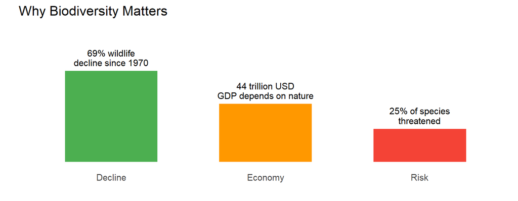

- **Ecosystem services**: Clean air, water filtration, pollination
- **Medicine**: 70% of cancer drugs come from natural sources
- **Food security**: Genetic diversity protects crops from disease
- **Ökosystemleistungen**: Saubere Luft, Wasserfilterung, Bestäubung
- **Medizin**: 70% der Krebsmedikamente stammen aus natürlichen Quellen
- **Ernährungssicherheit**: Genetische Vielfalt schützt Pflanzen vor Krankheiten

# The Sampling ProblemDas Stichproben-Problem

## The Counting ProblemDas Zählproblem

**How many plant species are in Austria?**

Can we count them all? Consider:

- Austria = 83,879 km²
- Some species are tiny (mosses, lichens)
- Some only appear in certain seasons
- Some are extremely rare

**The answer: Sampling!**

We study small areas carefully and use statistics to estimate the total.

**Wie viele Pflanzenarten gibt es in Österreich?**

Können wir alle zählen? Bedenke:

- Österreich = 83.879 km²
- Manche Arten sind winzig (Moose, Flechten)
- Manche erscheinen nur zu bestimmten Jahreszeiten
- Manche sind extrem selten

**Die Lösung: Stichproben!**

Wir untersuchen kleine Flächen sorgfältig und nutzen Statistik zur Schätzung.

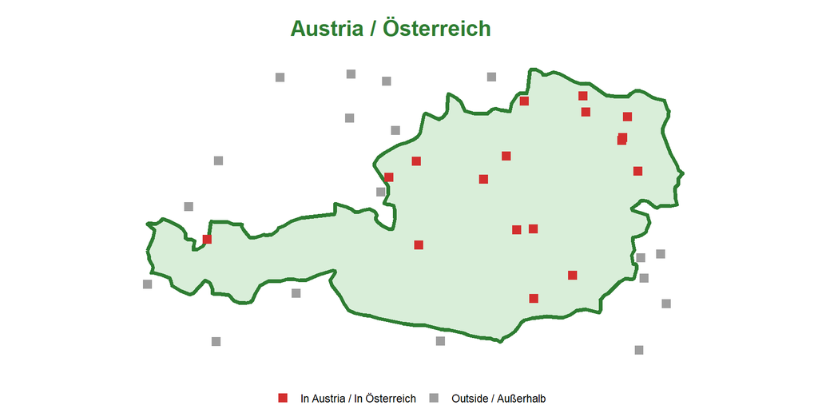

**Key insight:** We study small plots carefully, then use patterns to understand the whole.

**Kernidee:** Wir untersuchen kleine Flächen sorgfältig und nutzen Muster, um das Ganze zu verstehen.

## Discussion QuestionDiskussionsfrage

Imagine you want to know how many different types of candy exist in a candy store.

You have **5 minutes** and can look in **10 jars** (out of 100 total jars).

**Which strategy is better?**

1. Look at the 10 jars closest to the door
2. Look at 10 jars spread throughout the store

**Why does this matter for ecology?**

Stell dir vor, du willst wissen, wie viele verschiedene Süßigkeiten es in einem Süßwarenladen gibt.

Du hast **5 Minuten** und kannst in **10 Gläser** schauen (von insgesamt 100).

**Welche Strategie ist besser?**

1. Die 10 Gläser direkt neben der Tür
2. 10 Gläser verteilt im ganzen Laden

**Warum ist das für Ökologie wichtig?**

## Vegetation PlotsVegetationsplots

A **vegetation plot** is a small area (typically 1-100 m²) where ecologists record every plant species.

| What we record | Example |
| --- | --- |
| Location (coordinates) | 47.0707° N, 15.4395° E |
| Date | 2023-06-15 |
| All species present | Festuca rubra, Trifolium repens, … |
| Cover (%) per species | 25%, 10%, … |

Ein **Vegetationsplot** ist eine kleine Fläche (typisch 1-100 m²), auf der Ökologen jede Pflanzenart notieren.

| Was wir aufnehmen | Beispiel |
| --- | --- |
| Standort (Koordinaten) | 47.0707° N, 15.4395° E |
| Datum | 2023-06-15 |
| Alle vorhandenen Arten | Festuca rubra, Trifolium repens, … |
| Deckung (%) pro Art | 25%, 10%, … |

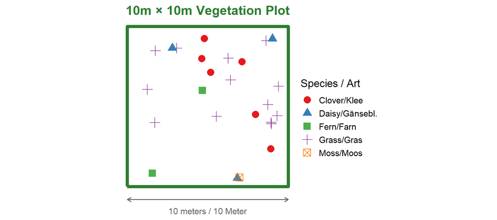

# Species Accumulation CurvesArtenakkumulationskurven

## The Core IdeaDie Kernidee

As we sample more plots, we find more species - but at a **decreasing rate**.

**Why?**

- First plots: Mostly **common** species (easy to find)
- Later plots: Mostly **rare** species (hard to find)
- Eventually: Very few new species per plot

Je mehr Plots wir untersuchen, desto mehr Arten finden wir - aber mit **abnehmender Rate**.

**Warum?**

- Erste Plots: Hauptsächlich **häufige** Arten (leicht zu finden)
- Spätere Plots: Hauptsächlich **seltene** Arten (schwer zu finden)
- Schließlich: Sehr wenige neue Arten pro Plot

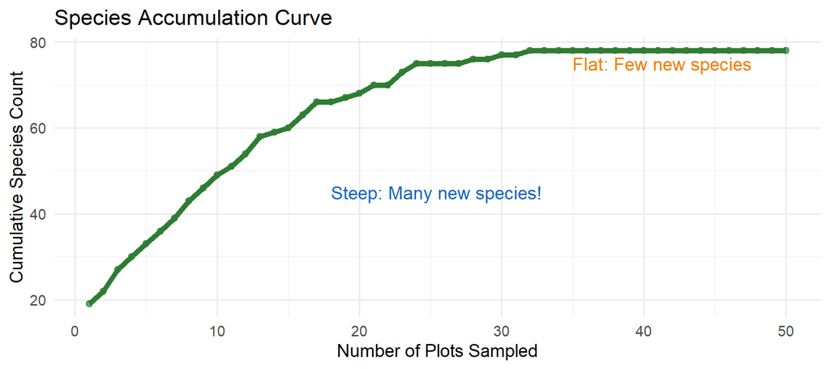

## Why Does the Curve Flatten?Warum flacht die Kurve ab?

Think of it like a **card game**:

| Draw # | What happens |
| --- | --- |
| 1st card | Definitely new! |
| 10th card | Probably still new |
| 30th card | Maybe seen it before |
| 50th card | Very likely a repeat |

**The more species you’ve already found, the harder it is to find new ones.**

Denk an ein **Kartenspiel**:

| Karte # | Was passiert |
| --- | --- |
| 1. Karte | Definitiv neu! |
| 10. Karte | Wahrscheinlich noch neu |
| 30. Karte | Vielleicht schon gesehen |
| 50. Karte | Sehr wahrscheinlich ein Duplikat |

**Je mehr Arten du schon gefunden hast, desto schwieriger wird es, neue zu finden.**

## Let’s Build One TogetherLasst uns eine Kurve bauen

Imagine we’re sampling a meadow. Each “plot” reveals some species:

| Plot | Species.Found | New.Species | Cumulative.Total |
| --- | --- | --- | --- |
| 1 | Daisy, Clover, Grass | 3 | 3 |
| 2 | Buttercup, Dandelion, Grass | 2 | 5 |
| 3 | Daisy, Thistle, Clover | 1 | 6 |
| 4 | Grass, Plantain, Daisy | 1 | 7 |
| 5 | Clover, Buttercup, Yarrow | 1 | 8 |
| 6 | Daisy, Grass, Clover | 0 | 8 |
| 7 | Dandelion, Plantain, Grass | 0 | 8 |
| 8 | Clover, Daisy, Sorrel | 1 | 9 |

**Notice:** By plot 6-7, we’re not finding anything new!

Stell dir vor, wir untersuchen eine Wiese. Jeder “Plot” zeigt einige Arten:

| Plot | Gefundene.Arten | Neue.Arten | Kumulativ |
| --- | --- | --- | --- |
| 1 | Gänseblümchen, Klee, Gras | 3 | 3 |
| 2 | Butterblume, Löwenzahn, Gras | 2 | 5 |
| 3 | Gänseblümchen, Distel, Klee | 1 | 6 |
| 4 | Gras, Spitzwegerich, Gänseblümchen | 1 | 7 |
| 5 | Klee, Butterblume, Schafgarbe | 1 | 8 |
| 6 | Gänseblümchen, Gras, Klee | 0 | 8 |
| 7 | Löwenzahn, Spitzwegerich, Gras | 0 | 8 |
| 8 | Klee, Gänseblümchen, Sauerampfer | 1 | 9 |

**Beachte:** Bei Plot 6-7 finden wir nichts Neues mehr!

## Visualizing Our ExampleUnsere Beispielkurve

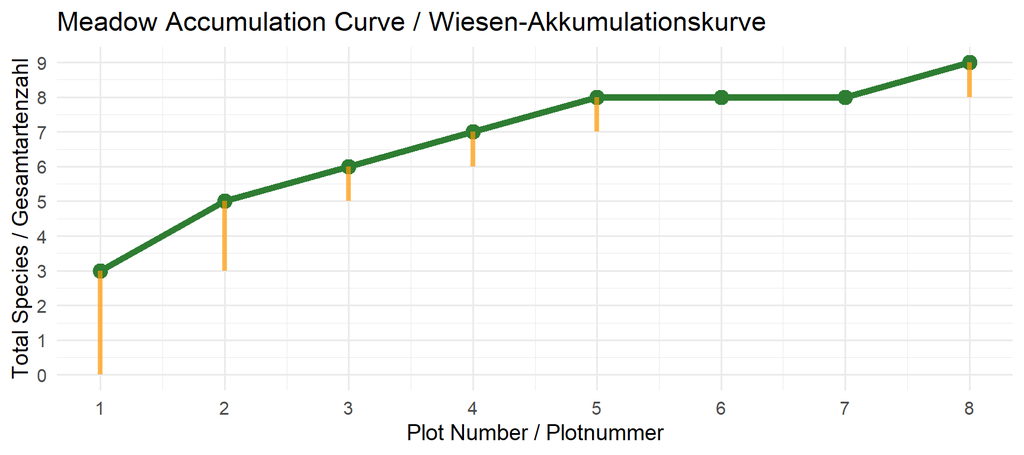

The **orange segments** show how many new species each plot adds. Notice how they get shorter!

Die **orangenen Segmente** zeigen, wie viele neue Arten jeder Plot hinzufügt. Beachte, wie sie kürzer werden!

## Discussion QuestionDiskussionsfrage

Look at these two curves:

Schau dir diese zwei Kurven an:

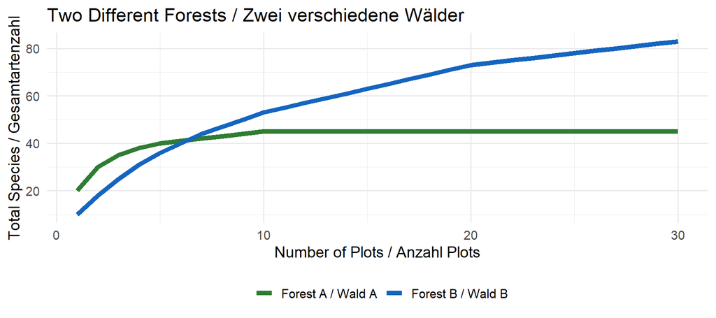

**Questions:**

1. Which forest probably has more total species?
2. Which forest has species spread more evenly?
3. In which forest would you need to sample MORE plots to find everything?

**Fragen:**

1. Welcher Wald hat wahrscheinlich mehr Arten insgesamt?
2. In welchem Wald sind die Arten gleichmäßiger verteilt?
3. In welchem Wald müsstest du MEHR Plots untersuchen, um alles zu finden?

# The AsymptoteDie Asymptote

## Predicting the UnknowableDas Unbekannte vorhersagen

The **asymptote** is the line the curve approaches but never quite reaches.

It represents: **the estimated total number of species**

Even without sampling everything, we can estimate how much we’re missing!

Die **Asymptote** ist die Linie, der sich die Kurve nähert, aber nie ganz erreicht.

Sie repräsentiert: **die geschätzte Gesamtartenzahl**

Selbst ohne alles zu untersuchen, können wir schätzen, wie viel wir verpassen!

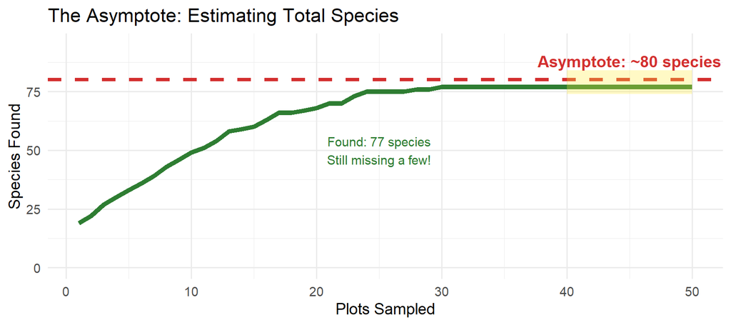

# The European Vegetation ArchiveDas Europäische Vegetationsarchiv

## EVA DatabaseEVA-Datenbank

**EVA** (European Vegetation Archive) is the largest vegetation database in Europe:

- **1.6+ million** plots
- **82** countries
- Data from **1900 to today**

For Austria, we have access to ~52,000 plots with location data.

**EVA** (European Vegetation Archive) ist die größte Vegetationsdatenbank Europas:

- **1,6+ Millionen** Plots
- **82** Länder
- Daten von **1900 bis heute**

Für Österreich haben wir Zugang zu ~52.000 Plots mit Standortdaten.

## Native vs. Alien SpeciesHeimische vs. Alien-Arten

Our dataset distinguishes between:

| Native Species | Alien Species (Neophytes) |
| --- | --- |
| Naturally occurring | Introduced by humans |
| Part of original ecosystem | Arrived after 1492 |
| Co-evolved with other species | May outcompete natives |

**Research Question for Day 2:** Do alien species accumulate differently than native species?

Unser Datensatz unterscheidet zwischen:

| Heimische Arten | Alien-Arten (Neophyten) |
| --- | --- |
| Natürlich vorkommend | Vom Menschen eingeführt |
| Teil des ursprünglichen Ökosystems | Nach 1492 angekommen |
| Mit anderen Arten co-evolviert | Können Einheimische verdrängen |

**Forschungsfrage für Tag 2:** Akkumulieren Alien-Arten anders als heimische Arten?

# Why Not Excel?Warum nicht Excel?

## Excel is Great For…Excel ist super für…

You probably know Excel well. It’s perfect for:

- Quick calculations
- Simple tables and charts
- Small datasets (hundreds of rows)

**Could we build accumulation curves in Excel?** Yes! For a small example:

Du kennst wahrscheinlich Excel gut. Es ist perfekt für:

- Schnelle Berechnungen
- Einfache Tabellen und Diagramme
- Kleine Datensätze (Hunderte von Zeilen)

**Könnten wir Akkumulationskurven in Excel bauen?** Ja! Für ein kleines Beispiel:

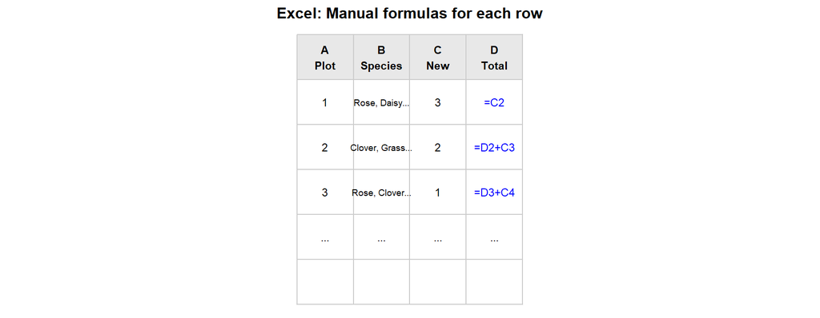

This works fine for 5 plots. But what about **52,000 plots**?

Das funktioniert für 5 Plots. Aber was ist mit **52.000 Plots**?

## But Real Research Needs MoreAber echte Forschung braucht mehr

Our Austrian dataset has **52,000 plots** and **850,000 species observations**.

| Task | Excel | R |
| --- | --- | --- |
| Load 850,000 rows | Crashes or freezes | 2 seconds |
| Repeat analysis 100 times | Click 100 times | One loop |
| Share exact method | “I clicked here, then there…” | Share the code |
| Find a bug | Where did I click wrong? | Read line 47 |
| Update with new data | Start over | Re-run script |

Unser österreichischer Datensatz hat **52.000 Plots** und **850.000 Artenbeobachtungen**.

| Aufgabe | Excel | R |
| --- | --- | --- |
| 850.000 Zeilen laden | Stürzt ab oder friert ein | 2 Sekunden |
| Analyse 100x wiederholen | 100x klicken | Eine Schleife |
| Exakte Methode teilen | “Ich habe hier geklickt, dann dort…” | Code teilen |
| Fehler finden | Wo habe ich falsch geklickt? | Zeile 47 lesen |
| Mit neuen Daten aktualisieren | Von vorne anfangen | Skript erneut ausführen |

## Reproducibility: The Key DifferenceReproduzierbarkeit: Der Schlüsselunterschied

In science, others must be able to **reproduce** your results.

With Excel: > “I sorted column B, then filtered for values > 10, then made a chart, then… I think I also removed some outliers?”

With R:

```r
data %>%
  filter(value > 10) %>%
  ggplot(aes(x, y)) +
  geom_line()
```

**The code IS the method.** Anyone can run it and get the same result.

In der Wissenschaft müssen andere deine Ergebnisse **reproduzieren** können.

Mit Excel: > “Ich habe Spalte B sortiert, dann nach Werten > 10 gefiltert, dann ein Diagramm erstellt, dann… ich glaube, ich habe auch einige Ausreißer entfernt?”

Mit R:

```r
data %>%
  filter(value > 10) %>%
  ggplot(aes(x, y)) +
  geom_line()
```

**Der Code IST die Methode.** Jeder kann ihn ausführen und das gleiche Ergebnis erhalten.

# SummaryZusammenfassung

## Key ConceptsSchlüsselkonzepte

| Concept | What it means |
| --- | --- |
| **Biodiversity** | Variety of species in an area |
| **Vegetation plot** | Small area where all plants are recorded |
| **Accumulation curve** | Graph showing species discovery over sampling effort |
| **Asymptote** | Estimated total species (curve approaches but never reaches) |
| **Native species** | Naturally occurring in the region |
| **Alien species** | Introduced by humans (after 1492) |

| Konzept | Bedeutung |
| --- | --- |
| **Biodiversität** | Artenvielfalt in einem Gebiet |
| **Vegetationsplot** | Kleine Fläche, auf der alle Pflanzen erfasst werden |
| **Akkumulationskurve** | Graph der Artenentdeckung über Stichprobenaufwand |
| **Asymptote** | Geschätzte Gesamtartenzahl (Kurve nähert sich, erreicht sie aber nie) |
| **Heimische Arten** | Natürlich in der Region vorkommend |
| **Alien-Arten** | Vom Menschen eingeführt (nach 1492) |

## Preview: Day 2Vorschau: Tag 2

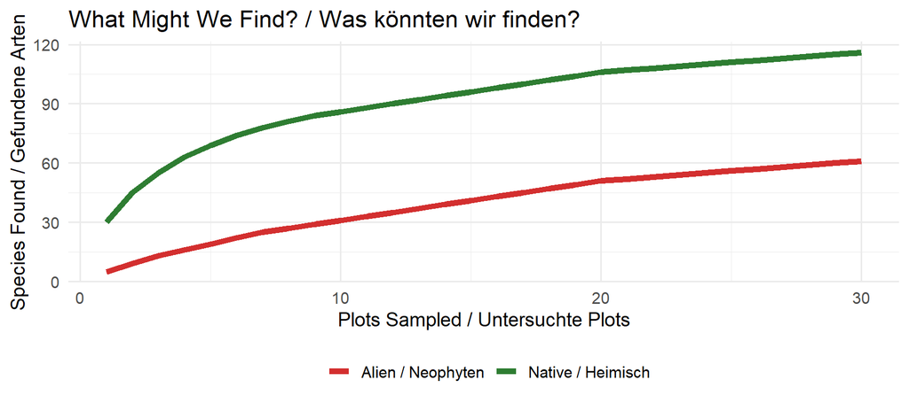

Tomorrow we will:

1. Learn the **nearest-neighbor algorithm** for building spatial curves
2. Understand why **plot order matters**
3. Build curves with **multiple starting points**
4. Compare **native vs. alien** accumulation patterns
5. Interpret results and discuss **biological mechanisms**

**Hypothesis to test:** Do alien species accumulate differently than native species?

Morgen werden wir:

1. Den **Nearest-Neighbor-Algorithmus** für räumliche Kurven lernen
2. Verstehen, warum die **Plot-Reihenfolge wichtig** ist
3. Kurven mit **mehreren Startpunkten** bauen
4. **Heimische vs. Alien**-Akkumulationsmuster vergleichen
5. Ergebnisse interpretieren und **biologische Mechanismen** diskutieren

**Zu testende Hypothese:** Akkumulieren Alien-Arten anders als heimische Arten?